# R Notebook

# Libraries

```r
library(scales)
```

# Reading in Data

```r
# read in our cleaned data
regional <- read_csv("clean_data/regional_domestic_tourism.csv")
accom <- read_csv("clean_data/scottish_accomodation_occupancy.csv")
activities <- read_csv("clean_data/tourism_day_visits_activities.csv")
demo <- read_csv("clean_data/tourism_day_visits_demographics.csv")
location <- read_csv("clean_data/tourism_day_visits_location.csv")
transport <- read_csv("clean_data/tourism_day_visits_transport.csv")
inter <- read_csv("clean_data/int_data")
```

# Q1 - Activities

• What kind of tourism activity generates the highest income for Scotland? To answer this lets look at the table activities and summarise the different activities in order of expenditure

```r
head(activities)
```

| date_code | units | value | tourism_activity | breakdown_of_domestic_tourism |
| --- | --- | --- | --- | --- |
| 2019 | million pounds (GBP) | 1662 | Shopping for items that you do not regularly buy | Expenditure |
| 2016 | million pounds (GBP) | 469 | Watched live sporting events (not on TV) | Expenditure |
| 2014 | million pounds (GBP) | 892 | Night out to a bar, pub and/or club | Expenditure |
| 2017 | million pounds (GBP) | 354 | Special personal events e.g. wedding, graduation | Expenditure |
| 2015 | million pounds (GBP) | 400 | Watched live sporting events (not on TV) | Expenditure |
| 2014 | million pounds (GBP) | 421 | Watched live sporting events (not on TV) | Expenditure |

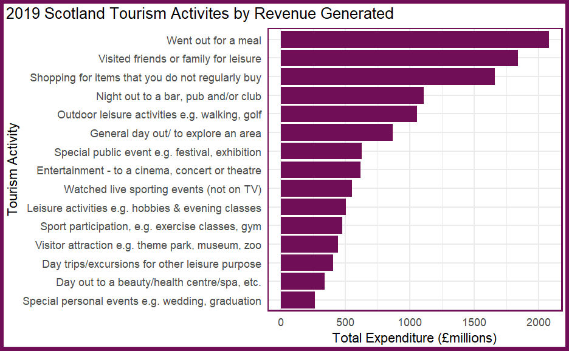

```r
activities %>%
  filter(breakdown_of_domestic_tourism == "Expenditure",
         tourism_activity != "All",
         date_code == 2019) %>%
  group_by(tourism_activity) %>%
  summarise(total_value = sum(value)) %>%
  arrange(desc(total_value)) %>%
  ggplot(aes(x = reorder(tourism_activity, total_value), y = total_value))+
  geom_col(fill = "#700e57")+
  coord_flip()+
  theme_minimal()+
  labs(title = "2019 Scotland Tourism Activites by Revenue Generated",
       y = "Total Expenditure (£millions)",
       x = "Tourism Activity")+
  theme(plot.caption = element_text(hjust = 0, face= "italic"),
        plot.title.position = "plot", #NEW parameter. Apply for subtitle too.
        plot.caption.position =  "plot")+
  theme_minimal()+
  theme(panel.border = element_rect(colour = "#700e57", fill=NA, size=1),
        plot.background = element_rect(colour = "#700e57", fill=NA, size=3),
        plot.caption = element_text(hjust = 0, face= "italic"),
        plot.title.position = "plot", #NEW parameter. Apply for subtitle too.
        plot.caption.position =  "plot")
```

```r
NA
NA
```

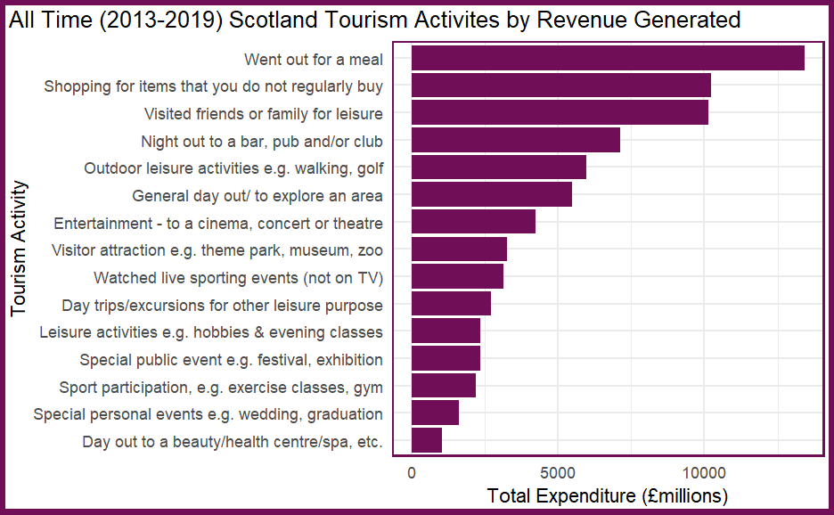

```r
activities %>%
  filter(breakdown_of_domestic_tourism == "Expenditure",
         tourism_activity != "All") %>%
  group_by(tourism_activity) %>%
  summarise(total_value = sum(value)) %>%
  arrange(desc(total_value)) %>%
  ggplot(aes(x = reorder(tourism_activity, total_value), y = total_value))+
  geom_col(fill = "#700e57")+
  coord_flip()+
  theme_minimal()+
  labs(title = "All Time (2013-2019) Scotland Tourism Activites by Revenue Generated",
       y = "Total Expenditure (£millions)",
       x = "Tourism Activity")+
  theme(plot.caption = element_text(hjust = 0, face= "italic"),
        plot.title.position = "plot", #NEW parameter. Apply for subtitle too.
        plot.caption.position =  "plot")+
  theme_minimal()+
  theme(panel.border = element_rect(colour = "#700e57", fill=NA, size=1),
        plot.background = element_rect(colour = "#700e57", fill=NA, size=3),
        plot.caption = element_text(hjust = 0, face= "italic"),
        plot.title.position = "plot", #NEW parameter. Apply for subtitle too.
        plot.caption.position =  "plot")
```

```r
NA
```

want a top 6 over time plot

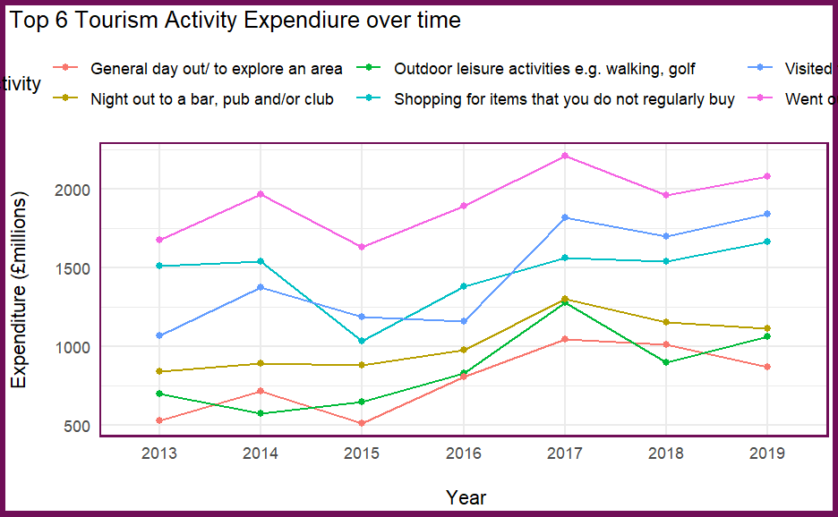

```r
activities %>%
  filter(tourism_activity %in% top_6_activities,
         breakdown_of_domestic_tourism == "Expenditure") %>%
  ggplot(aes(x = date_code, y = value, colour = tourism_activity))+
  geom_line()+
  scale_x_discrete(limits = (activities$date_code))+
  geom_point()+
  labs(title = "Top 6 Tourism Activity Expendiure over time",
       x = "\n Year",
       y = "Expenditure (£millions)\n ",
       color='Tourism Activity')+
  theme(plot.caption = element_text(hjust = 0, face= "italic"),
        plot.title.position = "plot", #NEW parameter. Apply for subtitle too.
        plot.caption.position =  "plot")+
  theme_minimal()+
  theme(panel.border = element_rect(colour = "#700e57", fill=NA, size=1),
        plot.background = element_rect(colour = "#700e57", fill=NA, size=3),
        plot.caption = element_text(hjust = 0, face= "italic"),
        plot.title.position = "plot", #NEW parameter. Apply for subtitle too.
        plot.caption.position =  "plot",
        legend.position="top")
```

> visits and activities are generally going up over this period

# Q2 Activity - Visits

Which kind of activity generates the most visits to sites?

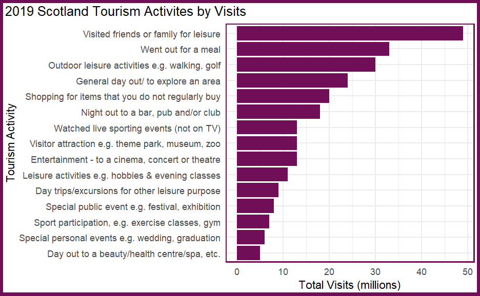

# Visits over time

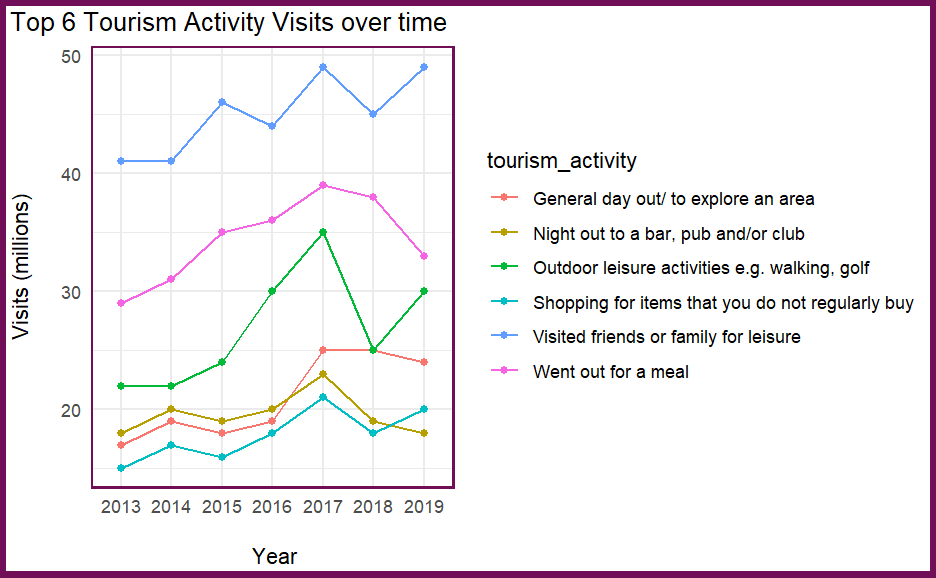

```r
activities %>%
  filter(tourism_activity %in% top_6_activities,
         breakdown_of_domestic_tourism == "Visits") %>%
  ggplot(aes(x = date_code, y = value, colour = tourism_activity))+
  geom_line()+
  scale_x_discrete(limits = (activities$date_code))+
  geom_point()+
  labs(title = "Top 6 Tourism Activity Visits over time",
       x = "\n Year",
       y = "Visits (millions)\n ")+
  theme(plot.caption = element_text(hjust = 0, face= "italic"),
        plot.title.position = "plot", #NEW parameter. Apply for subtitle too.
        plot.caption.position =  "plot")+
  theme_minimal()+
  theme(panel.border = element_rect(colour = "#700e57", fill=NA, size=1),
        plot.background = element_rect(colour = "#700e57", fill=NA, size=3),
        plot.caption = element_text(hjust = 0, face= "italic"),
        plot.title.position = "plot", #NEW parameter. Apply for subtitle too.
        plot.caption.position =  "plot")
```

> Visits on all but nights out at bars are going up over time so the increase expensiture we saw cant all be associated with inflation. Big drop (10m!) in Outdoor leaisure activities 2017-2018 despite was the UK’s warmest summer since 2006, the driest since 2003 and the sunniest since 1995.Was it too nice a summer? Look at non - summarised data would be good.

#Q3 Demographics Is there a particular key demographic of visitors we should be focusing on? Who spends the most? Who visits the most?

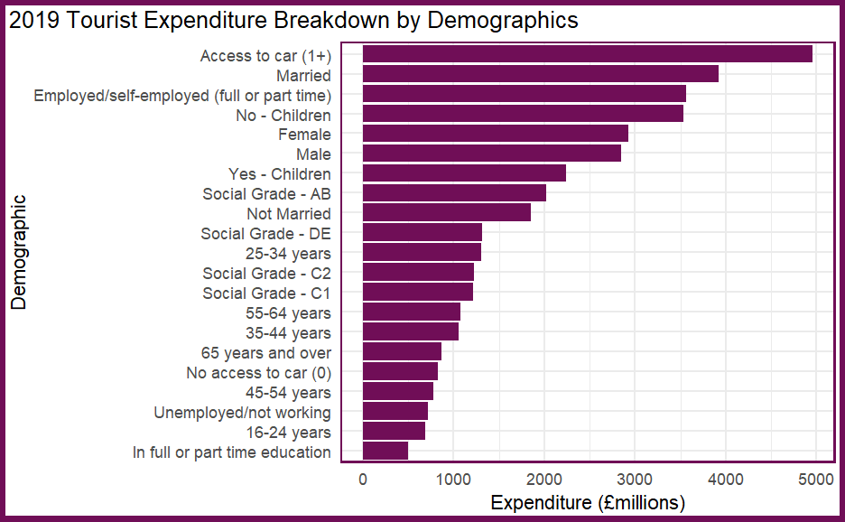

> In the expenditure certain standouts include the AB social group taking a jump from the visits graph, this stands to reason with more disposable income. Students again last.

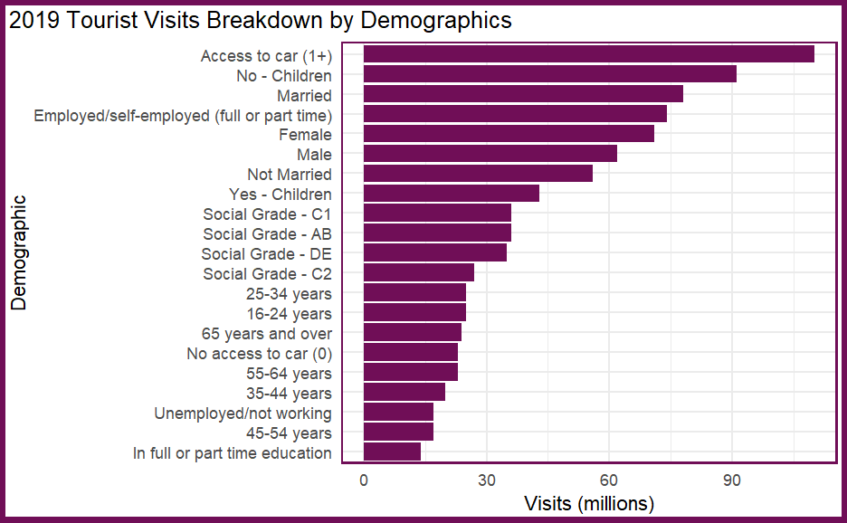

> Primary Market seems to be people with car access, with no kids, married and employed either full or part time. There is a big gulf between with kids and no kids. Again this data has been pre summarised so its difficult to drill down further into this but we can draw these simple conclusions

# Q4 Location

• What type of locations receive the most visits? What kinds of locations do people spend the most in?

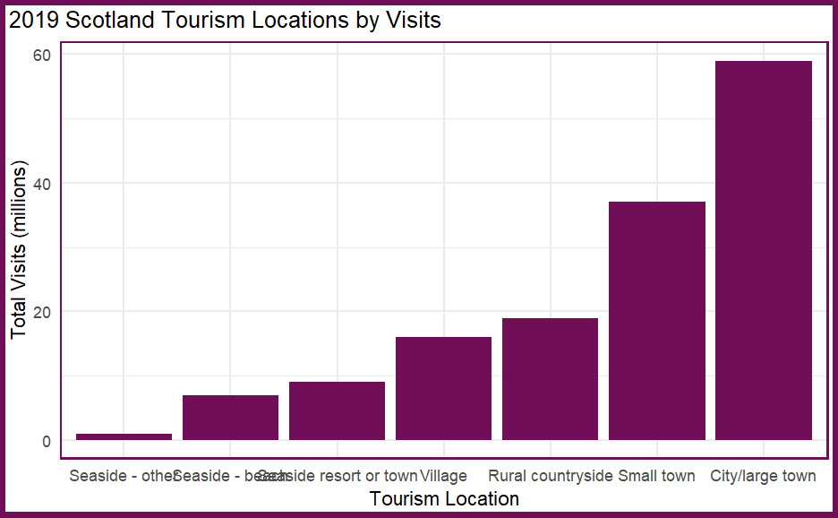

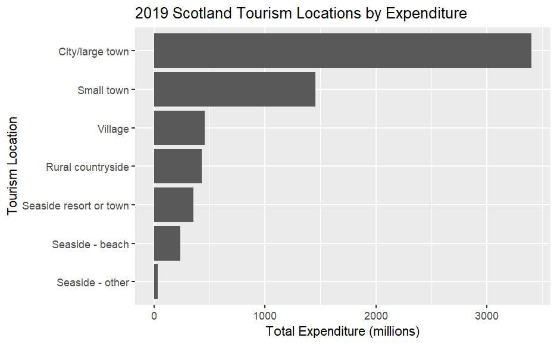

```r
location %>%
  filter(breakdown_of_domestic_tourism == "Expenditure",
         type_of_location_visited != "All areas",
         date_code == 2019) %>%
  group_by(type_of_location_visited) %>%
  summarise(total_value = sum(value)) %>%
  arrange(desc(total_value)) %>%
  ggplot(aes(x = reorder(type_of_location_visited, total_value), y = total_value))+
  geom_col()+
  coord_flip()+
  labs(title = "2019 Scotland Tourism Locations by Expenditure",
       y = "Total Expenditure (millions)",
       x = "Tourism Location")
```

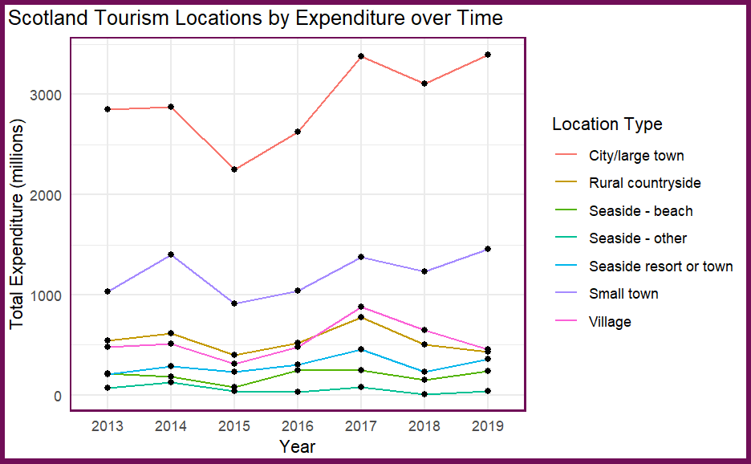

```r
location %>%
  filter(type_of_location_visited != "All areas",
         breakdown_of_domestic_tourism == "Expenditure") %>%
  group_by(type_of_location_visited) %>%
  select(c(type_of_location_visited, date_code, value)) %>%
  ggplot(aes(x = date_code, y = value))+
  geom_line(aes(colour = type_of_location_visited))+
  geom_point()+
  labs(title = "Scotland Tourism Locations by Expenditure over Time",
       y = "Total Expenditure (millions)",
       x = "Year",
       color='Location Type')+
  scale_x_discrete(limits = (location$date_code))+
  theme_minimal()+
  theme(panel.border = element_rect(colour = "#700e57", fill=NA, size=1),
        plot.background = element_rect(colour = "#700e57", fill=NA, size=3),
        plot.caption = element_text(hjust = 0, face= "italic"),
        plot.title.position = "plot", #NEW parameter. Apply for subtitle too.
        plot.caption.position =  "plot")
```

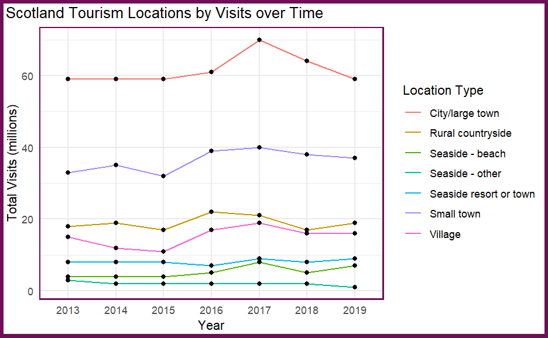

```r
location %>%
  filter(type_of_location_visited != "All areas",
         breakdown_of_domestic_tourism == "Visits") %>%
  group_by(type_of_location_visited) %>%
  select(c(type_of_location_visited, date_code, value)) %>%
  ggplot(aes(x = date_code, y = value))+
  geom_line(aes(colour = type_of_location_visited))+
  geom_point()+
  labs(title = "Scotland Tourism Locations by Visits over Time",
       y = "Total Visits (millions)",
       x = "Year",
       color='Location Type')+
  scale_x_discrete(limits = (location$date_code))+
  theme_minimal()+
  theme(panel.border = element_rect(colour = "#700e57", fill=NA, size=1),
        plot.background = element_rect(colour = "#700e57", fill=NA, size=3),
        plot.caption = element_text(hjust = 0, face= "italic"),
        plot.title.position = "plot", #NEW parameter. Apply for subtitle too.
        plot.caption.position =  "plot")
```

> Cities and large towns are by far the most popular destinations. Possibly this is skewed as the data includes a lot of going out for meals?